# Your Digest for Thursday, Oct 26, 2023 11:59 PM

Acute effusions are usually due to some type of bleeding -> acute -> symptomatic at low volumes.

# Cerebral infarction pathology

[Source](https://emedicine.medscape.com/article/1916852-overview#a4)

- Ischemia -> hypoxia -> low ATP -> ⬇ Na/K pump activity -> *Na influx + passive water influx* + calcium *influx*; water influx causes 'cytotoxic oedema'
- ⬇ Na/C exchange pump -> calcium influx -> excitatory neurotransmitter release -> amplification of ischemic insult.
  - Activation of enzymes -> more cell injury.
- Collateral supply may preserve blood flow; deep structures like thalamus, basal ganglia and internal capsule supplied by perforating arteries *do not have collateral* supplies.
- Areas with severe ischemia **die within 10 minutes**.
- Areas around this are the penumbra; they remain viable for **several hours!**
- With loss of ATP, neurons become depolarized. (loss of membrane potential)
- Ischemia causes **breakdown of blood brain barrier** -> protein and water enters extracellular space -> **vasogenic oedema** -> **peaks at 3-5 days**
- These changes promote further ischemia of the penumbra.
- Ischemia affects oligodendrocytes and astrocytes as well.
- Liquefactive necrosis occurs.
- **Timeline**
  - Macrocopic
    - Upto 6 hours, nothing.
    - From then to 48 hours, swelling and pallor.
    - From then to 10 days, tissue becomes friable.
    - day 10 to *week 3*: liquefactive necrosis occurs.
  - Microscopic
    - First 12 hours: swelling, ischemic neural changes -> 'red neurons'
    - Upto 48 hours: neutrophil migration
    - 2 - 3 weeks: macrophage migration
    - During phagocytosis, astrocytes **enlarge**, **divide** and form a network of cytplasmic extension.

# Inactivation of sex chromatin

Sex chromatin = Barr body.  
[Source](https://www.khanacademy.org/science/biology/classical-genetics/sex-linkage-non-nuclear-chromosomal-mutations/a/x-inactivation)

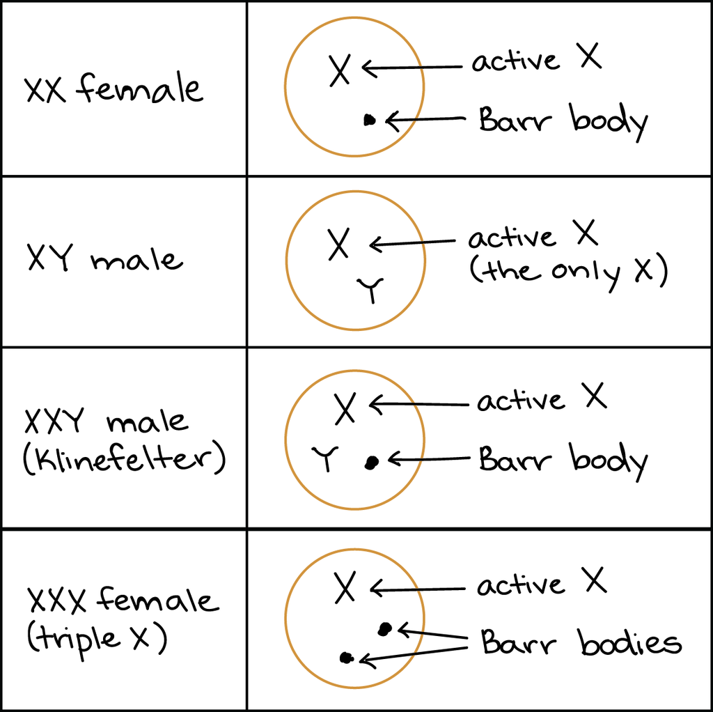

# Random note on muscarinic receptors

> **Muscarinic receptors** are **G-coupled protein receptors involved in the parasympathetic nervous system**. The only exception to these receptors is the sweat glands, which possess muscarinic receptors but are part of the sympathetic nervous system. [Source](https://www.ncbi.nlm.nih.gov/books/NBK555909/)  
> Mnemonic: Musca-para-Gee

# Spinal shock

A transient loss of all spinal cord activity below a spinal cord insult including flaccid paralysis, paraesthesia, loss of bladder and bowel control, loss of reflexes, priapism in males, bradycardia and hypotension.  
Lasts around 2 weeks.

Possible mechanisms: Increased intra spinal cord pottassium levels;  
release from descending tract inhibition of *inhibitory neurons* -> leading to inhibition of motor neurons;

Denervation hypersensitivity plays a role in recovery.

## 📑Overview of atherosclerosis

> [!INFO] Response to vessel injury  
> Vessel injury of any cause produces the same stereotyped response. Intimal thickening is a stereotypical response to vessel injury.  
> Mechanism: Intimal injury stimulates *migration* of smooth muscle cells from the *media* **OR** *from circulating precursors!*. They arrive in the intima, undergo mitosis and *produces extracellular matrix*, forming a *'neointima'*. This is analogous to scar formation elsewhere. Neointimal smooth muscle cells are **non contractile** but can undergo mitosis and greater synthetic capacity. This altered activation of neointimal smooth muscle cells is *driven by cytokines* produced by **platelets, macrophages, endothelial cells and circulating complement and coagulation factors**. Cytokines involved are **PDGF, FGF, TGF-alpha** (Platelet derived growth factors, Fibroblast growth factors, TGF-alpha).  
> Removal of the harmful stimulus will revert the phenotype of neotintimal muscle cells to their *non proliferative* (medial smooth muscle is non proliferative) state but the thickening they have produced is irreversible.  
> Intimal thickening is **also a normal part of aging** but because of outward remodeling, does not narrow vessels.

Risk factors for atherosclerosis have roughly **multiplicative effects**. 2 factors -X2 risk, 3 factors X7 risk.  
Risk factors:  
**Dietary**:

- High intake of saturated fats raises lipid levels.
- Trans unsaturated fats found in margarine are bad.
- Omega 3 fatty acids in fish are good.
- Exercise and *moderate consumption* of ethanol *raises HDL levels*.
- CRP produced by 'cells in the plaque' increase adhesiveness of endothelial cells and *CRP* **independently and strongly correlated with risk of infarction.**
- Lipoprotein a increases risk.
1. *Endothelial dysfunction*
   1. Involving altered gene expression (eg. *incr. adhesion molecules*) and *increased permeability* of endothelial cells.
   2. This allows migration of blood **monocytes** into the *intima* where they become **macrophages**.
2. *Increased lipids in the blood*
   1. **Cholesterol** and it's esters are found inside plaques. *They stimulate chronic inflammation* in the intima in the presence of macrophages.  
      In the presence of lipids within the intima, macrophages become activated. When they 📑engulf lipids, they become **foam cells.**  
      *Cytokines* **secreted by macrophages** stimulate altered function and growth of *smooth muscle cells* **of the media**.  
      📑Smooth muscle cells proliferate and take on fibroblastic roles.  
      Smooth muscles + **collagen** produced by them form the fibrous cap of the plaque.

> [!INFO] The response to injury hypothesis of atherosclerosis
> 1. Views atherosclerosis as a chronic inflammatory process.
> 2. There is interaction of lipoproteins, macrophages, T lymphocytes to cause progression of the lesion
> 3. Main components of atherosclerosis:
> 4. **Endothelial injury** with ⬆ adhesiveness and ⬆ permeability - the **main component**. Atherosclerosis begins at **intact** but dysfunctional endothelium.
>    1. Endothelial dysfunction is promoted mainly by altered haemodynamics and hypercholesterolemia.
>       1. Haemodynamics: Turbulence; as occurs at ostia, branch points and posterior wall of the aorta. Laminar flow is *protective* via gene induction.
>       2. Hypercholesterolaemia - 1) directly causes endothelial dysfunction, 2)Promotes inflammation by formation of oxidised LDL and cholesterol crystals
>    2. Dysfunctional endothelium promotes adhesion of inflmmatory cells including macrophages (which *engulf LDL* to become foam cells) and T lymphocytes (which set up chronic inflammation).
> 5. **Platelet adhesion**
> 6. **Monocyte / macrophage** adhesion and adtivation
> 7. **lipid and lipoprotein** accumulation
> 8. **Smooth muscle cell recruitment** by mediators produced by platelets, macrophages
> 9. **Smooth muscle cell *proliferation***.
- The earliest lesion is a **Fatty streak**. Componsed of Foam cells but *not raised*.
- **Aortic** fatty streaks are present in all **children**.
- **Coronary** fatty streaks form during **adolescence**.
- **Not all fatty streaks progress to atherosclerotic plaques**.
- Some are converted to '**mature atheroma**' by smooth muscle proliferation and matrix synthesis.
  - Mature atheromas have **CELLS, MATRIX and LIPIDS**.
- Key feature of atherosclerotic plaque is **intimal thickening** and lipid accumulation.
  - They are white / yellow **raised** lesions.
  - They involve only a part of the cirumference of the wall. ('patchy')
  - Frequency of atheroma formation
    - Infrarenal aorta > Coronaries > poplitieal arteries > internal carotid > Circle of willis
    - Mnemonic: **A Clever Parrot Imitates Words**

[figure not shown]

    - Upper limbs, renal arteries and mesenteric arteries are usually spared.
    - Lesions at various stages coexist in the same vessel.

Morphology:

- The shoulder of the plaque is more cellular.
- Acellular components are fibrin, collagen and proteoglycan.
- Cholesterol clefts are seen because cholesterol crystal present in plaques are removed by processing.
- Periphery of plaques **show neovascularization!**
- Plaques progressively enlarge. They can undergo **calcification**.

> The majority of plaque ruptures occurs in the proximal and middle of coronary arteries and distal ruptures are rare.  
> [Source](https://www.ncbi.nlm.nih.gov/pmc/articles/PMC4960071/)